# RBGlass1 Model Example

MDH

September 24, 2016

## Identifying Roman Glass Site Provenience

This data set details the concentrations for 11 major and minor elements in 105 Romano-British waste glass specimens from two furnace sites, Leicester and Mancetter. This short analysis includes two portions, 1) use `dplyr` and `ggplot` to see the distributions of trace elements between the two furnace sites; and 2) use a machine learning technique to classify the observations by furnace, predict the furnace of test observations, establish the error rate, and finally visualize which trace elements contribute to correct classifications.

#### Note about ggplot2 version

this relies on the development version of ggplot2 for the subtitle and caption text. To install this version, first install the `devtools` package `install.packages("devtools")`, then install ggplot from github `devtools::install_github("hadley/ggplot2")`. If you do not do this and have the CRAN version, everything should work except the subtitle and caption, and you will get a warning.

### Load packages

```r
library("archdata") # for RBGlass1 data
library("xgboost") # Extremee Gradient Boosting model
library("Ckmeans.1d.dp") # for plotting variable importance
library("ggplot2") # Development version, see note above
library("dplyr") # for data munging
library("reshape2") # for melt()
library("tidyr") # for separate()
```

### Grab data and assign

```r
# from archdata package
data(RBGlass1)
# to save some key strokes
rbg <- RBGlass1
# table of number of obervations for each furnace
table(rbg$Site)
```

```
Leicester Mancetter
       59        46
```

### Reshape data

```r
rbg_elements <- group_by(rbg, Site) %>%
  summarise_each(funs(mean, median, sd)) %>%
  t %>%
  as.data.frame( stringsAsFactors = FALSE) %>%
  tibble::rownames_to_column() %>%
  rename(Leicester = V1,  Mancetter = V2) %>%
  filter(!grepl('Site', rowname)) %>%
  mutate(Leicester = round(as.numeric(Leicester),3),
         Mancetter = round(as.numeric(Mancetter),3)) %>%
  separate(rowname, into = c("element", "measure"), sep = "_") %>%
  print
```

```
   element measure Leicester Mancetter
1       Al    mean     2.377     2.469
2       Fe    mean     0.696     0.476
3       Mg    mean     0.548     0.533
4       Ca    mean     6.586     7.192
5       Na    mean    18.202    17.202
6        K    mean     0.707     0.720
7       Ti    mean     0.100     0.080
8        P    mean     0.117     0.139
9       Mn    mean     0.273     0.414
10      Sb    mean     0.259     0.094
11      Pb    mean     0.032     0.025
12      Al  median     2.350     2.445
13      Fe  median     0.740     0.480
14      Mg  median     0.550     0.530
```

[output cut: 19 more lines]

#### Plot a representation

The `ggplot` below takes the results of the previous processing, filters to the mean measurement, and plots them over elements by furnace.

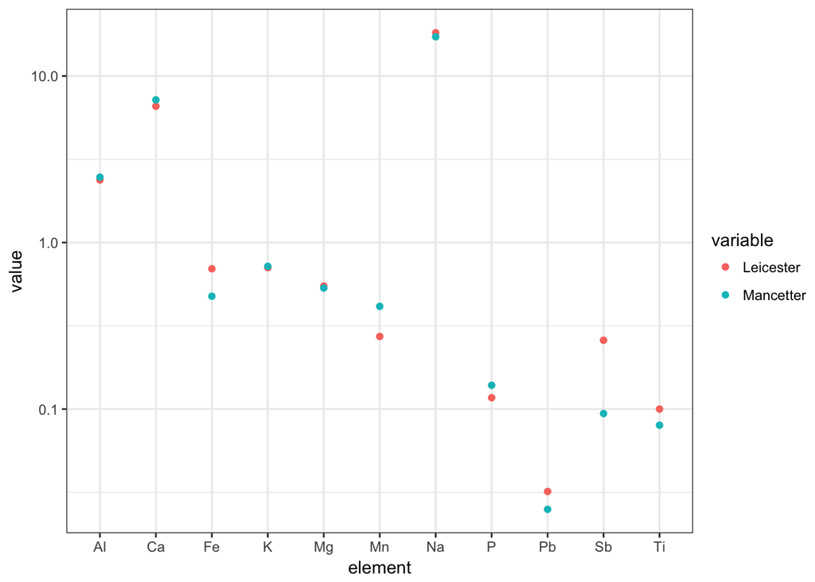

```r
rbg_plot_mean <- reshape2::melt(rbg_elements) %>%
  filter(measure == "mean") %>%
  ggplot(aes(x = element, y = value, color = variable)) +
           geom_point() +
  scale_y_log10() +
  theme_bw()
rbg_plot_mean
```

## Model with Machine Learning

Described as simply modeling, statistical learning, or machine learning the process of training models via the optimization of hyper parameters for the purpose of prediction is a very powerful approach in modern statistics and data science. In a somewhat false dichotomy, statistical learning is differentiated from statistical analysis by the goal of the modeling enterprise; prediction vs. inference. Below is a quick example of using a very popular learning algorithm, extreme gradient boosting, for the classification of Roman glass furnaces and an exploration of which elements differentiate them. There are a number of clustering methods that could also be used to approach these data.

### Split data into train (75%) and test (25%) data sets

A very important part of establishing error rates for model prediction includes testing the model on an independent data set. The approach taken here uses a simple split sample (75%/25%) for model training and testing. In a more realistic setting, a more rigorous approach, such as k-folds Cross Validation, would be used. Split sampling is not an inherently bad technique, but it can lead to high variance and possible over fitting if the samples are not representative of the population. But for this demo, it is sufficient.

```r
# convert the factor values of the furnace sites (1,2) to a binary (0,1) numeric values
rbg$Site <- as.numeric(rbg$Site)-1
# set random seed
set.seed(3323)
# take a random 75% sample of row numbers from the data
train_index <- sample(nrow(rbg), floor(nrow(rbg)*0.75))
# assign the just the rows randomly sampled above to the training dataset
train_dat <- rbg[train_index,]
# assign all rows except the training rows to the test data
test_dat <- rbg[-train_index,]
```

### Train XGB model on traning data

The `xgboost` package implements a supervised regression/classification model called *extreme gradient boosting*. In a very simple description, you can think of this model as a sequence of simple regression models that are repeated a over and over trying to improve the errors from the previous round. The basic theory that makes this work is that a many weak models can be added together to create a strong model. For further study of [Statistical Learning](http://www-bcf.usc.edu/~gareth/ISL/) techniques, this side and book are highly recommended.

Training a model in R is deceptively simple. Simple because the syntax to do so is fairly consistent between packages and typically the default parameter values are reasonably set. They can be used as black boxes without much thought, but it is highly suggested that you spend time learning about how the model works and tuning hyper-parameters to go the best fit for your purpose. This demo will used the `xgboost` defaults.

The `data` argument in the `xgboost()` function gets passed the training data, but as doing so it is converted from a data.frame to a matrix with `as.matrix()` function and the first row of the training data is dropped through `[,-1]`. The first row is the `Site` column containing the furnace designation.

The `label` argument is the furnace designation as the `Site` column. The `nrounds` argument is the number of repetitions that model goes through to improve results. The `objective` argument is where we tell the model to perform linear regression or logistic regression for classification.

```r
model1 <- xgboost(data = as.matrix(train_dat[,-1]),
                  label = train_dat$Site,
                  nrounds = 10,
                  objective = "binary:logistic")
```

### Make predictions based on test data

From the trained model, predictions can be made on new data. In this case, the new data is the 25% held-out sample. The test data.frame is passed to the `predict()` function in the same way as the test data; converted to a matrix and dropped the first column. We do not need to pass the `label` argument to to `predict()` because the true class labels (furnace) are not needed to predict.

In the second line, a new `data.frame` is made by creating two rows, the `predicted` values and the `observed` values. Note that the predictions are within the range of `[0,1]` so a threshold of `0,5` is used to classify the predictions into the predicted furnace designation, `0` or `1`.

```r
pred1 <- predict(model1, newdata = as.matrix(test_dat[,-1]))
prediction <- data.frame(predicted = as.numeric(pred1 > 0.5),
                         observed = test_dat$Site)
```

### Confusion Matrix and Error Rate

A confusion matrix is a table that shows the predictions and observations in a 2-way table that depicts true-positive, false-positive, and true and false negatives. Following the confusion matrix, an absolute error rate is calculated as simply the percent incorrect predictions.

```r
prediction$predicted <- ifelse(prediction$predicted == 1,
                               "Leicester", "Mancetter")
prediction$observed <- ifelse(prediction$observed == 1,
                               "Leicester", "Mancetter")
table(prediction)
```

```
           observed
predicted   Leicester Mancetter
  Leicester         8         5
  Mancetter         1        13
```

```r
err <- mean(prediction$predicted != prediction$observed)
print(paste("test-error =", round(err,3)*100, "%"))
```

```
[1] "test-error = 22.2 %"
```

### Varaible Importance

Finally, the xgboost algorithm, as well as some other similar algorithms, allow for the calculation of variable importance (VI). A number of methods can be used to estimate VI, including random permutation, Gini distance, out-of-bag-error, etc… The end result is an attempt to quantify which variables contributed to the correct predictions. Here we use the `xgb.importance()` function on our training data and fit model. The results are printed and then plotted as a `ggplot` object.

```r
importance_matrix <- xgb.importance(colnames(train_dat[,-1]),
                                    model = model1)
print(importance_matrix)
```

```
   Feature        Gain       Cover  Frequence
1:      Sb 0.461947953 0.257637185 0.21568627
2:      Mn 0.231375417 0.287851352 0.25490196
3:      Mg 0.116641687 0.127218241 0.09803922
4:      Ca 0.069455065 0.118077729 0.17647059
5:      Fe 0.057636633 0.130135033 0.11764706
6:       P 0.045385213 0.043253919 0.05882353
7:       K 0.016504830 0.030316922 0.05882353
8:      Al 0.001053203 0.005509618 0.01960784
```

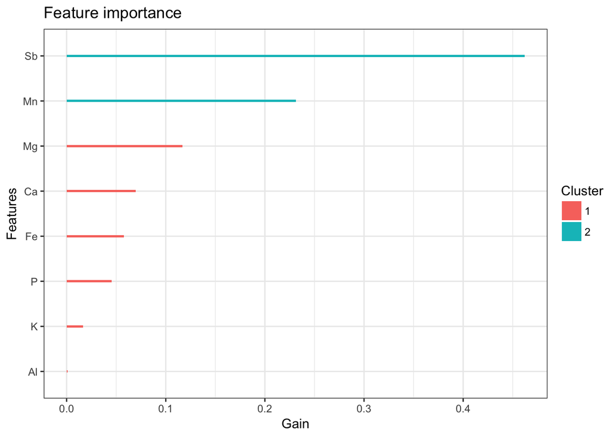

```r
xgb.plot.importance(importance_matrix = importance_matrix) +
  theme_bw()
```

## Dataset Information

#### Details

The concentrations for 11 major and minor elements in 105 Romano-British waste glass specimens from two furnace sites (Leicester and Mancetter) come from Caroline Jackson’s Ph. D. thesis at Bradford University. The data here were scanned from from Baxter (1994) Table A1. Measurements are percentage for each element.

#### Source

Baxter, M. J. 1994. Exploratory Multivariate Analysis in Archaeology. Edinburgh University Press. Jackson, C. M. 1992. A Compositional Analysis of Roman and Early Post-Roman Glass and Glass Working Waste from Selected British Sites Towards an Understanding of the Technology of GlassMaking Through Analysis by Inductively-Coupled Plasma Spectrometry. Unpublished PhD thesis. Bradford University (BL: D214554).